# The tale of two charts combined

data-visualization

highcharts

…Or when two half chart are more than one, or maybe: The love between the streamgraph and stack column chart… In this post we’ll review some ideas in the chart used by Financial Times in it’s Coronavirus tracker, and how we can replicate it in R using highcharter package.

Joshua Kunst http://jkunst.com/  
06-24-2020

*Post updated on Jan 05, 2021*

## Introducction

Week ago I see a tweet from Steven Bernard [@sdbernard](https://twitter.com/sdbernard) from Financial Times showing a *streamgraph* on the top of a *stacked column chart*. I take a look some seconds and then boom: What a combination! Why?

> One of them is the complement of the other.

The link for the original source is [here](https://www.ft.com/content/aa84f572-f7af-41a8-be41-e835bddbed5b).

[figure not shown]

Figure 1: Figure from Financial Times article

I like the streamgraph but it is hard to see the change the distribution between categories when the total change sudden. So have this auxiliar chart is a nice add to don’t loose from sigth the distribution.

## Data

In this post we will use the [Our Workd In Data](https://ourworldindata.org/) Covid deaths (link [here](https://ourworldindata.org/covid-deaths)) because I’m not sure what is the data used by Financial Times team.

We’ll load the data and check the structure and get only what we need to replitcate the chart:

```
library(tidyverse)
library(lubridate)

data <- readr::read_csv("https://covid.ourworldindata.org/data/owid-covid-data.csv")

# glimpse(data)

data %>% count(continent)
```

```
# A tibble: 7 x 2
  continent         n
  <chr>         <int>
1 Africa        15924
2 Asia          14675
3 Europe        14662
4 North America  7009
5 Oceania        1547
6 South America  3685
7 <NA>            683
```

```
data <- data %>%
  filter(!is.na(continent)) %>%
  select(continent, iso_code, date, location, new_deaths)

glimpse(data)
```

```
Rows: 57,502
Columns: 5
$ continent  <chr> "Asia", "Asia", "Asia", "Asia", "Asia", "Asia"...
$ iso_code   <chr> "AFG", "AFG", "AFG", "AFG", "AFG", "AFG", "AFG...
$ date       <date> 2020-02-24, 2020-02-25, 2020-02-26, 2020-02-2...
$ location   <chr> "Afghanistan", "Afghanistan", "Afghanistan", "...
$ new_deaths <dbl> NA, NA, NA, NA, NA, NA, NA, NA, NA, NA, NA, NA...
```

FT used the *7-day rolling average* in the chart so we’ll use the {RcppRoll} package to get that series for each contienent. Check the next code to see how the function `roll_meanr` works.

```
RcppRoll::roll_meanr(1:10, n = 3)
```

```
 [1] NA NA  2  3  4  5  6  7  8  9
```

Now we need to group the data to calculate the roll mean for every country/location and then filter to reduce some noise.

```
data <- data %>%
  arrange(continent, iso_code, date) %>%
  group_by(iso_code, continent, location) %>%
  mutate(
    new_deaths_7day_rollmean = RcppRoll::roll_meanr(new_deaths, n = 7),
    new_deaths_7day_rollmean = ifelse(is.na(new_deaths_7day_rollmean), 0, new_deaths_7day_rollmean),
    new_deaths_7day_rollmean = round(new_deaths_7day_rollmean)
    ) %>%
  ungroup()

data <- data %>%
  filter(date >= lubridate::ymd(20200315))
```

The chart show continent so we’ll group by date and continent.

```
dcont <- data %>%
  group_by(date, continent) %>%
  summarise(
    new_deaths = sum(new_deaths_7day_rollmean)
  )

glimpse(dcont)
```

```
Rows: 1,780
Columns: 3
Groups: date [297]
$ date       <date> 2020-03-15, 2020-03-15, 2020-03-15, 2020-03-1...
$ continent  <chr> "Africa", "Asia", "Europe", "North America", "...
$ new_deaths <dbl> 0, 99, 268, 7, 0, 0, 0, 110, 323, 11, 0, 0, 0,...
```

## The streamgraph

Before combine two charts we need to know how to get every chart independently. Let’s start with the main one:

```
library(highcharter)

hchart(dcont, "streamgraph", hcaes(date, new_deaths, group = continent))
```

[interactive chart not shown]

A good start, but we can do it better. So, some considerations:

- The yAxis don’t have a meaning in the streamgraph so we’ll remove it.
- We can set `endOnTick` and `startOnTick` en yAxis to gain some extra vertical space.
- Remove the vertical lines to get a more clear chart.
- Get a better tooltip (`table = TRUE`).
- In this case but we can try adding labels to each series instead of using legend, same as the FT chart.
- This is not associate to the chart itself but what is representing: In the original FT chart some countries like *UK*, *US* are separated for their continent because are relevant, and then the color used is similar to their continent to get the visual association.

To separate the information for some coutries from theirs continent we’ll create a `grp` variable:

```
ctry_to_separate <- c("Brazil", "Mexico", "Chile", "United Kingdom",
                      "United States", "India", "Russia")

data <- data %>%
  mutate(
    grp = ifelse(
      location %in% ctry_to_separate,
      location,
      continent
    )
  )

data %>%
  count(continent, grp)
```

```
# A tibble: 13 x 3
   continent     grp                n
   <chr>         <chr>          <int>
 1 Africa        Africa         15692
 2 Asia          Asia           13281
 3 Asia          India            296
 4 Europe        Europe         13033
 5 Europe        Russia           296
 6 Europe        United Kingdom   296
 7 North America Mexico           296
 8 North America North America   6168
 9 North America United States    297
10 Oceania       Oceania         1437
11 South America Brazil           296
12 South America Chile            297
13 South America South America   2960
```

**Fun part #1**: To the continent which have separated countries will add the `"Rest of "` to be specific this is no the total continent.

```
data <- data %>%
  group_by(continent) %>%
  mutate(
    grp = case_when(
      all(grp == continent) ~ grp,
      grp == continent ~ str_c("Rest of ", continent),
      TRUE ~ grp
      )
    ) %>%
  ungroup()

data %>%
  count(continent, grp)
```

```
# A tibble: 13 x 3
   continent     grp                       n
   <chr>         <chr>                 <int>
 1 Africa        Africa                15692
 2 Asia          India                   296
 3 Asia          Rest of Asia          13281
 4 Europe        Rest of Europe        13033
 5 Europe        Russia                  296
 6 Europe        United Kingdom          296
 7 North America Mexico                  296
 8 North America Rest of North America  6168
 9 North America United States           297
10 Oceania       Oceania                1437
11 South America Brazil                  296
12 South America Chile                   297
13 South America Rest of South America  2960
```

**Fun part #2**: We’ll use a specific color for each continent, and a brighten variation for the the separated countries. For this task the {shades} package offer the `brightness` function.

```
# install.packages("shades")
library(shades)

palette <- c("#f1c40f", "#d35400", "#2980b9", "#2c3e50", "#7f8c8d", "#2ecc71")

# data %>%
#   count(continent, grp)

dlvls_n_clrs <- data %>%
  group_by(continent, grp) %>%
  summarise(n = sum(new_deaths_7day_rollmean)) %>%
  # to get the "rest or the continent" first for colors
  mutate(aux = str_detect(grp, continent)) %>%
  arrange(continent, desc(aux), desc(n)) %>%
  left_join(
    data %>% distinct(continent) %>% mutate(continent_color = palette[1:dplyr::n()]),
    by = "continent"
  ) %>%
  group_by(continent) %>%
  mutate(fct = seq(from = 0, to = 0.10, length.out = dplyr::n())) %>%
  ungroup() %>%
  rowwise() %>%
  mutate(grp_color = unlist(list(shades::brightness(continent_color, delta(fct))))) %>%
  mutate(continent_cln = janitor::make_clean_names(continent)) %>%
  # to get the "rest or the continent" last for order tooltip
  arrange(continent, aux, desc(n))

knitr::kable(dlvls_n_clrs)
```

| continent | grp | n | aux | continent_color | fct | grp_color | continent_cln |
| --- | --- | --- | --- | --- | --- | --- | --- |
| Africa | Africa | 65430 | TRUE | #f1c40f | 0.00 | #F1C40F | africa |
| Asia | India | 149113 | FALSE | #d35400 | 0.10 | #EC5E00 | asia |
| Asia | Rest of Asia | 185594 | TRUE | #d35400 | 0.00 | #D35400 | asia |
| Europe | United Kingdom | 73931 | FALSE | #2980b9 | 0.05 | #2C89C6 | europe |
| Europe | Russia | 56723 | FALSE | #2980b9 | 0.10 | #2F92D2 | europe |
| Europe | Rest of Europe | 415733 | TRUE | #2980b9 | 0.00 | #2980B9 | europe |
| North America | United States | 347056 | FALSE | #2c3e50 | 0.05 | #33485D | north_america |
| North America | Mexico | 126109 | FALSE | #2c3e50 | 0.10 | #3A526A | north_america |
| North America | Rest of North America | 34912 | TRUE | #2c3e50 | 0.00 | #2C3E50 | north_america |
| Oceania | Oceania | 913 | TRUE | #7f8c8d | 0.00 | #7F8C8D | oceania |
| South America | Brazil | 195018 | FALSE | #2ecc71 | 0.05 | #31D978 | south_america |
| South America | Chile | 16639 | FALSE | #2ecc71 | 0.10 | #34E67F | south_america |
| South America | Rest of South America | 151317 | TRUE | #2ecc71 | 0.00 | #2ECC71 | south_america |

Then exctract some vectors:

```
lvls <- pull(dlvls_n_clrs, grp)
cont <- pull(dlvls_n_clrs, continent_cln)

cols1 <- dlvls_n_clrs %>% filter(aux) %>% pull(grp_color)
cols2 <- dlvls_n_clrs %>% pull(grp_color)
```

Before continuing let’s see the original colors and the finishes obtained with the {shades} package.

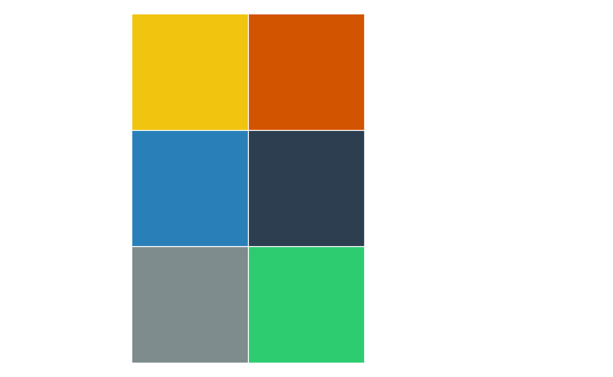

Figure 2: Original palette

```
scales::show_col(cols1, labels = FALSE, borders = FALSE, ncol = 2)
```

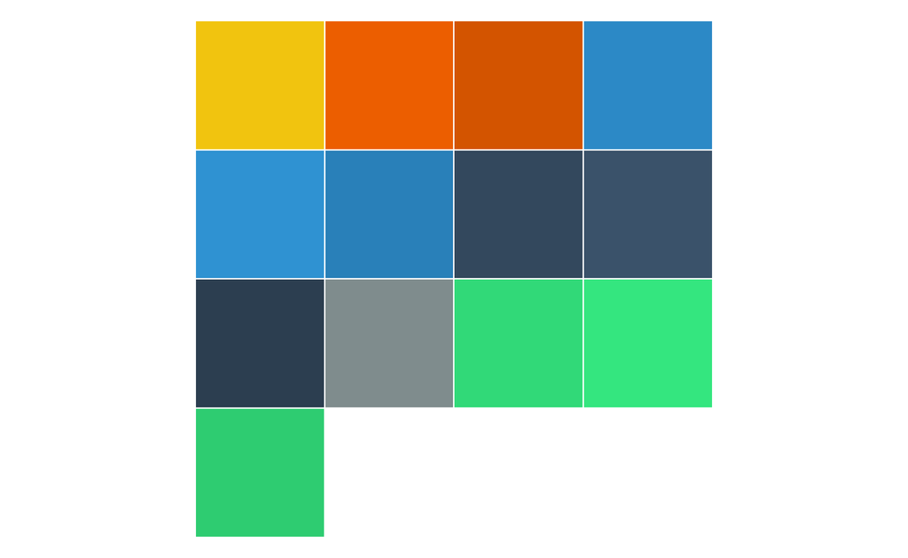

Figure 3: Colors considering variations

```
scales::show_col(cols2, labels = FALSE, borders = FALSE)
```

The colors and levels are ready so let’s regroup the data using this new `grp` variable:

```
dcont_grp <- data %>%
  mutate(grp = factor(grp, levels = lvls)) %>%
  group_by(date, grp) %>%
  summarise(
    new_deaths = sum(new_deaths_7day_rollmean)
  )
```

Then plot the previous chart but now considering all the comments made before.

```
hchart(
  dcont_grp,
  "streamgraph",
  hcaes(date, new_deaths, group = grp),
  # this will be useful in the combine
  linkedTo = cont,
  showInLegend = FALSE,
  label = list(
    enabled = TRUE, minFontSize = 10, maxFontSize = 20,
    style = list(
      fontWeight = 100,
      textOutline = "1px gray",
      color = hex_to_rgba("white", 0.9)
      )
    )
  ) %>%
  hc_colors(cols2) %>%
  hc_yAxis(visible = FALSE, startOnTick = FALSE, endOnTick = FALSE) %>%
  hc_xAxis(gridLineWidth = 0) %>%
  hc_tooltip(table = TRUE, outside = TRUE)
```

[interactive chart not shown]

## The stacked column chart

For the stacked column chart we’ll use the data which have deaths by continent (no `grp`). This is a simple chart so the only important part is set `borderWidth`, `groupPadding`, `pointPadding` to 0 to remove the space between columns.

```
hchart(
  dcont, "column", hcaes(date, new_deaths, group = continent),
  stacking = "percent",
  borderWidth = 0,
  groupPadding = 0,
  pointPadding  = 0,
  id = unique(cont)
  ) %>%
  hc_colors(cols1) %>%
  hc_size(height = 300)
```

[interactive chart not shown]

## The final chart

There are some important things to do before code the final chart:

- Create and add two yAxis using `hc_yAxis_multiples` and `create_yaxis` functions. One for each type of series. The two series will share the same xAxis.
- For the column series we’ll use the `id` parameter with the `unique(cont)` value, then in the streamgraph use the `linkedTo` parameter to link the series. With this the Russia, UK and Rest of Europe series from the streamgraph are link with the Europe series from the stacked column chart, so if the user click the Europa legend all those series will hide.

```
hcft <- highchart() %>%
  hc_add_series(
    dcont_grp,
    "streamgraph",
    hcaes(date, new_deaths, group = grp),
    # this will be useful in the combine
    linkedTo = cont,
    yAxis = 0,
    showInLegend = FALSE,
    label = list(
      enabled = TRUE, minFontSize = 10, maxFontSize = 20,
      style = list(
        fontWeight = 100,
        textOutline = "1px gray",
        color = hex_to_rgba("white", 0.9)
        )
      )
  ) %>%
  hc_add_series(
    dcont, "column", hcaes(date, new_deaths, group = continent),
    stacking = "percent",
    borderWidth = 0.00,
    groupPadding = 0.00,
    pointPadding  = 0.00,
    id = unique(cont),
    yAxis = 1,
    tooltip = list(pointFormat = "")
  ) %>%
  hc_colors(c(cols2, cols1)) %>%
  hc_yAxis_multiples(
    create_yaxis(
      naxis  = 2,
      height = c(4, 1),
      sep    = 0.00,
      offset = -20,
      turnopposite = TRUE,
      title  = list(text = NULL),
      visible = c(FALSE, TRUE),
      startOnTick = FALSE,
      endOnTick = FALSE
      )
    ) %>%
  hc_xAxis(type = "datetime", gridLineWidth = 0, title = list(text = NULL)) %>%
  hc_tooltip(
    # table = TRUE,
    # positioner = JS("function () { return { x: null, y: 50 };}"),
    outside = TRUE,
    shared = TRUE,
    useHTML = TRUE,
    headerFormat = "<small>{point.key}</small><table>",
    pointFormat = str_c("<tr><td style=\"color: {series.color}\">{series.name}: </td>",
                        "<td style=\"text-align: right\"><b>{point.y:0.f}</b></td>"),
    footerFormat = "<tr><td><b>Total</b>: </td><td style=\"text-align: right\"><b>{point.total:0.f}</b></td></tr></table>",
    style = list(fontSize = "0.7em")
    ) %>%
  hc_legend(
    verticalAlign = "top",
    align = "left",
    itemStyle =  list(fontWeight = 500)
    ) %>%
  hc_title(
    text = "Global Covid-19 death distribution"
  ) %>%
  hc_subtitle(
    text =  str_c(
      "Daily deaths of people diagnosed with coronavirus (7-day rolling average). ",
      "Ispiration (copied?!) from <a href='https://www.ft.com/content/a26fbf7e-48f8-11ea-aeb3-955839e06441'>Financial  Times</a> and ",
      "data from <a href='https://ourworldindata.org/covid-deaths'>ourworldindata.org</a>."
    )
  ) %>%
  # remove symbol markers
  hc_plotOptions(
    series = list(
      marker = list(radius = 0, enabled = FALSE, symbol = "circle"),
      states = list(hover = list(halo = list(size = 0)))
    )
  )
```

```
hcft %>%
  hc_size(height = 600)
```

[interactive chart not shown]

See full screen here.